# Pfizer: An Analysis and Speculation for Options Strategy

### Data 618, Midterm Project, October 11th 2020

## Pfizer and the COVID-19 Vaccine

Pfizer Inc. (\$PFE) is a biopharmaceutical company headquartered in New York City. The company IPO'ed on June 1st, 1972, and as of market close on October 9th, 2020 its shares are trading at $36.79.

Pfizer is widely considered to be a "blue chip" stock. The company has existed and has produced vaccines and drug delivery technology since 1882, when it developed the smallpox vaccine. Current annual revenue and market capitalization put the company squarely in the "large-cap" category of stocks, and Pfizer boasts a dividend yield of 4.12 percent, making it popular among conservatives investors.

As one of the pharmaceutical companies working on a COVID-19 vaccine, Pfizer is positioned to receive a massive windfall as a producer and distributor of the highly anticipated drug. Virtually all who can get the vaccine will want it (save for those who are anti-vax), both in the US and globally.

In May of 2020, Pfizer claimed that a vaccine would be ready "in the October time-frame" and that it would be prepared to distribute hundreds of millions of doses of the vaccine in early 2021. So far that estimate is incorrect, though there was (and still is) a major push to have a vaccine by Election Day. In July, it was revealed that the US government had signed an agreement with Pfizer for the delivery of 100 million doses of the vaccine, with the ability to acquire another 500 million doses. (https://www.hhs.gov/about/news/2020/07/22/us-government-engages-pfizer-produce-millions-doses-covid-19-vaccine.html)

Yet the production of this vaccine exposes Pfizer to some risks. Foremost, no vaccine has ever been developed, approved, and released in such a short timeframe. While the FDA has stringent requirements for new drug approval, there is political pressure from the Trump administration and from the pharma industry to fast-track the vaccine as it represents the best way to help the world return to some modicum of economic and social normalcy. The US government has coined the collaborative effort to create a vaccine as quickly as possible as "Operation Warp Speed." (https://www.politico.com/news/2020/10/09/coronavirus-vaccine-pfizer-election-day-428371)

If, somehow, the Pfizer vaccine is found to be faulty (perhaps due to a lack of long-term human drug trials) the company's reputation will take a major hit, significant amounts of R&D will have been wasted, already produced doses will have to be rejected, and more time will be needed to develop and approve a better version. This is probably the worst case scenario, and would not only negatively impact Pfizer's share price, but the entire global market and social order.

A more likely negative outcome is that the distribution of the vaccine is delayed beyond the targets set earlier in 2020. Stocks would probably slump (as they have numerous times already from bad news regarding a vaccine) but the effect on Pfizer's share price could be minimal as investors continue to anticipate a major jump when a viable vaccine is released.

## COVID-19 and the 2020 Stock Market

Let's take a look at the year 2020 in the stock market by importing some S&P 500 data.

```python
import pandas_datareader.data as web
import pandas as pd
import numpy as np
import matplotlib.pyplot as plt
import datetime as dt
```

```python
sp500_start = dt.datetime(2019,12,1)
sp500_end = dt.datetime(2020,10,9)

sp500 = web.DataReader('sp500', 'fred', sp500_start, sp500_end)
sp500.head()
```

| DATE | sp500 |
| --- | --- |
| 2019-12-02 | 3113.87 |
| 2019-12-03 | 3093.20 |
| 2019-12-04 | 3112.76 |
| 2019-12-05 | 3117.43 |
| 2019-12-06 | 3145.91 |

```python
%matplotlib inline
```

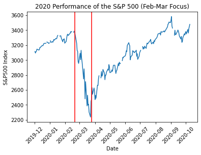

```python
# plot the S&P 500 data for 2020, highlighting Feb-Mar
plt.plot(sp500.index, sp500['sp500'])
plt.xlabel('Date')
plt.ylabel('S&P500 Index')
plt.title('2020 Performance of the S&P 500 (Feb-Mar Focus)')
plt.xticks(rotation=45)
plt.axvline(dt.datetime(2020,2,20),color='red')
plt.axvline(dt.datetime(2020,3,25),color='red')
```

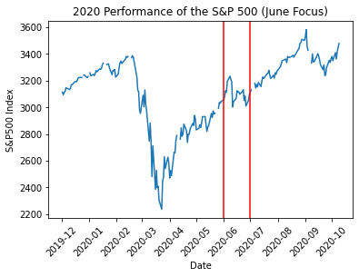

```python
# plot the S&P 500 data for 2020, highlighting June
plt.plot(sp500.index, sp500['sp500'])
plt.xlabel('Date')
plt.ylabel('S&P500 Index')
plt.title('2020 Performance of the S&P 500 (June Focus)')
plt.xticks(rotation=45)
plt.axvline(dt.datetime(2020,6,1),color='red')
plt.axvline(dt.datetime(2020,6,30),color='red')
```

June saw some of the worst market days since March/April due to pessimistic economic projections from the Federal Reserve and lackluster earnings reports from large tech companies. (https://newsaf.cgtn.com/news/2020-06-11/S-P-500-falls-3-on-new-virus-wave-fears-Fed-s-cautious-outlook-RfbkLEXisE/index.html)

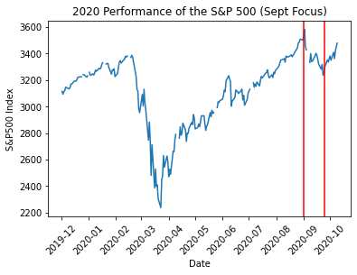

```python
# plot the S&P 500 data for 2020, highlighting June
plt.plot(sp500.index, sp500['sp500'])
plt.xlabel('Date')
plt.ylabel('S&P500 Index')
plt.title('2020 Performance of the S&P 500 (Sept Focus)')
plt.xticks(rotation=45)
plt.axvline(dt.datetime(2020,9,1),color='red')
plt.axvline(dt.datetime(2020,9,25),color='red')
```

The August rally and subsequent all-time high was partially attributed to drugmakers, like Pfizer, reporting progress in developing a COVID-19. The market saw another slump through most of September, with news publications blaming uncertainty in the US election, delays for a fiscal stimulus package, and more economic pessimism. (https://www.foxbusiness.com/markets/us-stocks-august-5-2020)

Another major negative news item in early September was that AstraZeneca's COVID-19 vaccine study was put on hold after a trial participant appeared to display an adverse reaction. The trial was resumed a few days later once the reaction was investigated. (https://www.beckershospitalreview.com/pharmacy/astrazeneca-trial-participant-who-had-adverse-reaction-experienced-transverse-myelitis-safety-report-shows.html)

### Takeaways

While the pandemic has had obvious effects on working Americans as unemployment rose to 15 percent and then "recovered" to 8 percent (where under 4 percent has been the norm), the effect on the stock market is more difficult to summarize.

Though there were major "red" days or even months, the overall market has all but recovered as it appears that investors who trust that the pandemic will eventually pass attempt to "buy the dip." Emotions are high as positive news concerning vaccine progress or fiscal stimulus is met with major surges in the market, while negative news can cause multiple day dips.

The market reaction to COVID-19 can be defined, foremost, by volatility.

## Pfizer and Drug Releases

Let's take a look a Pfizer's major accomplishments in drug production and distribution since their IPO in 1972, and see if there is any correlation to improved stock price.

From the Pfizer website (https://www.pfizer.com/science/vaccines/milestones):

```python
d = {'Year': [1988,1991,1993,1999,2000,2010,2011,2014,2015],
     'Accomplishment': ['Haemophilus influenzae vaccine',
                        'DTaP vaccine',
                        'Hib and DTP combined vaccine',
                        'Meningococcal serogroup C vaccine',
                        'PCV7 vaccine',
                        'PCV13 vaccine for children',
                        'PCV13 vaccine for adults',
                        'Meningococcal group B vaccine',
                        'Acquires Redvax GmBH']}

pfe_vaccines = pd.DataFrame(data=d)
pfe_vaccines
```

|  | Year | Accomplishment |
| --- | --- | --- |
| 0 | 1988 | Haemophilus influenzae vaccine |
| 1 | 1991 | DTaP vaccine |
| 2 | 1993 | Hib and DTP combined vaccine |
| 3 | 1999 | Meningococcal serogroup C vaccine |
| 4 | 2000 | PCV7 vaccine |
| 5 | 2010 | PCV13 vaccine for children |
| 6 | 2011 | PCV13 vaccine for adults |
| 7 | 2014 | Meningococcal group B vaccine |
| 8 | 2015 | Acquires Redvax GmBH |

We will attempt to see if any correlation between major releases and share price is visually apparent. We must import Pfizer share price data from its IPO to October 9th, 2020

```python
pfe_start = dt.datetime(1972,1,1)
pfe_end = dt.datetime(2020,10,9)

pfizer = web.DataReader('PFE','yahoo', pfe_start, pfe_end)
```

```python
pfizer.tail()
```

| Date | High | Low | Open | Close | Volume | Adj Close |
| --- | --- | --- | --- | --- | --- | --- |
| 2020-10-05 | 36.880001 | 36.340000 | 36.529999 | 36.750000 | 18406100.0 | 36.750000 |
| 2020-10-06 | 37.029999 | 36.090000 | 37.000000 | 36.169998 | 23940600.0 | 36.169998 |
| 2020-10-07 | 36.590000 | 36.029999 | 36.259998 | 36.470001 | 21024700.0 | 36.470001 |
| 2020-10-08 | 37.180000 | 36.509998 | 36.599998 | 36.889999 | 16942500.0 | 36.889999 |
| 2020-10-09 | 37.119999 | 36.590000 | 36.830002 | 36.790001 | 22448500.0 | 36.790001 |

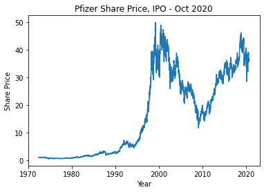

```python
plt.xlabel('Year')
plt.ylabel('Share Price')
plt.title('Pfizer Share Price, IPO - Oct 2020')
plt.plot(pfizer.index, pfizer['Close'])
```

A quick looks at the all-time share price chart appears to show a steady increase since the IPO, until a meteoric rise in the mid '90s, a volatile decrease until the 2008 financial crisis, and a recovery until 2020.

Let's add lines in the years where a major accomplishment occurred.

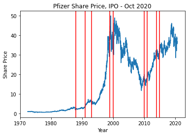

```python
plt.xlabel('Year')
plt.ylabel('Share Price')
plt.title('Pfizer Share Price, IPO - Oct 2020')
plt.plot(pfizer.index, pfizer['Close'])
plt.axvline(dt.datetime(1988,1,1),color='red')
plt.axvline(dt.datetime(1991,1,1),color='red')
plt.axvline(dt.datetime(1993,1,1),color='red')
plt.axvline(dt.datetime(1999,1,1),color='red')
plt.axvline(dt.datetime(2000,1,1),color='red')
plt.axvline(dt.datetime(2010,1,1),color='red')
plt.axvline(dt.datetime(2011,1,1),color='red')
plt.axvline(dt.datetime(2014,1,1),color='red')
plt.axvline(dt.datetime(2015,1,1),color='red')
```

Pfizer had no major vaccine breakthroughs between 1968 (development of the bifurcated needle) and 1988 (the first major accomplishment on our list) -- so it could be argued that the three vaccines developed in the late '80s and early '90s helped contribute to the increase seen from 1990 to 2000.

Of course, this analysis does not consider economic conditions of the time (such as the '90s dot-com boom and crash), but it appears that major vaccine development does loosely correlate with an increase in stock price, though it was exceedingly short-lived at the turn of the century.

Let's take a closer look at three periods that saw multiple vaccine developments: 1985-95, 1995-2001, and 2008-16.

```python
pfizer_85to95 = pfizer.loc['1985-01-01':'1995-01-01']
pfizer_95to01 = pfizer.loc['1995-01-01':'2001-01-01']
pfizer_08to16 = pfizer.loc['2008-01-01':'2016-01-01']
```

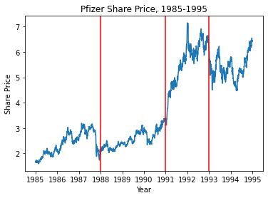

```python
plt.xlabel('Year')
plt.ylabel('Share Price')
plt.title('Pfizer Share Price, 1985-1995')
plt.plot(pfizer_85to95.index, pfizer_85to95['Close'])
plt.axvline(dt.datetime(1988,1,1),color='red')
plt.axvline(dt.datetime(1991,1,1),color='red')
plt.axvline(dt.datetime(1993,1,1),color='red')
```

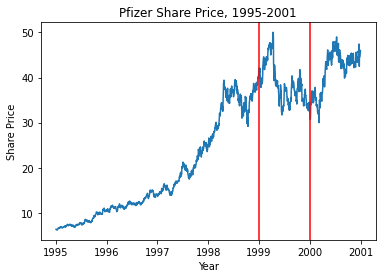

```python
plt.xlabel('Year')
plt.ylabel('Share Price')
plt.title('Pfizer Share Price, 1995-2001')
plt.plot(pfizer_95to01.index, pfizer_95to01['Close'])
plt.axvline(dt.datetime(1999,1,1),color='red')
plt.axvline(dt.datetime(2000,1,1),color='red')
```

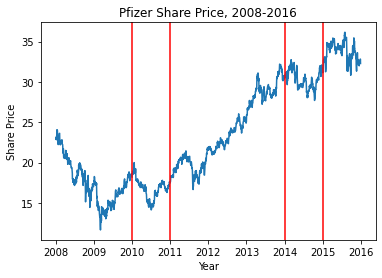

```python
plt.xlabel('Year')
plt.ylabel('Share Price')
plt.title('Pfizer Share Price, 2008-2016')
plt.plot(pfizer_08to16.index, pfizer_08to16['Close'])
plt.axvline(dt.datetime(2010,1,1),color='red')
plt.axvline(dt.datetime(2011,1,1),color='red')
plt.axvline(dt.datetime(2014,1,1),color='red')
plt.axvline(dt.datetime(2015,1,1),color='red')
```

### Takeaways

We want to avoid going too far into technical analysis of the chart movements particularly as we are not, at this point, considering the company's balance sheet during these periods - only share price and vaccine breakthroughs.

Pfizer has many drug licenses and other revenue producing products outside of their vaccines, as well as numerous subsidiaries that develop a large range of biopharmaceutical products -- vaccines do not tell the whole story.

## Options Strategies for Pfizer

Overall, this analysis is bullish on Pfizer -- they are among the biggest companies in the world, they are attractive to conservatives investors due to the high dividend, and they will most likely, eventually, develop a vaccine for COVID-19.

This analysis also recognizes the extreme levels of volatility in this market. Emotions have dictated market movements as people everywhere attempt to deal with economic and social fallout of the pandemic. The upcoming Presidential election is the most contentious in American history. The market was overdue for a correction or even recession according to some top economists before COVID-19 was the dominating news topic.

We will look into two options strategies for investing in Pfizer: a shorter-term neutral strategy that attempts to exploit the volatility as a result of the election and continued vaccine uncertainty, and a longer-term bullish strategy based on the promise of a vaccine and the windfall it will bring.

### Iron Condor for Short-Term Neutral Strategy

According to Investopedia, an iron condor is typically a neutral strategy and profits the most when the underlying asset doesn't move much. Both profit and risk are capped.

The iron condor is composed of four options: a bought put further OTM, a sold put closer to the money, a bought call further OTM, and a sold call closer to the money.

Ideally we want all the options to expire worthless.

As mentioned, Pfizer is currently trading at $36.79. As we want this to be a short-term strategy (taking advantage of the upcoming election) and minimize the risk of a large movement (such as if Pfizer announces success with the vaccine) we will look at calls and puts for November 6th, 2020.

A long put with a strike price of \$31 has an ask price of \\$0.09 (to be bought).

A short put with a strike price of \$35 has a bid price of \\$0.71 (to be sold).

A long call with a strike price of \$43 has an ask price of \\$0.21 (to be bought).

A short call with a strike price of \$39 has a bid price of \\$0.55 (to be sold).

So, we are selling a put and a call, and receiving \$71 + \\$55 = \$126.

And buying a put and a call for \$9 + \\$21 = \$30.

Once the orders are filled we have a \$96 profit -- our max profit.

Our max loss is the strike price of the long call - the strike price of the short call - net premium received (we are not considering commission -- let's pretend we are using a commission-free trading platform):

Let's take a look at the profit potential as Pfizer's stock price moves.

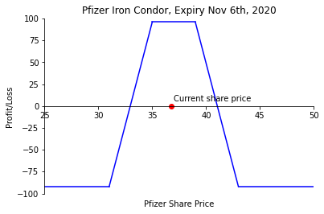

```python
fig = plt.figure()
ax = fig.add_subplot(1,1,1)
ax.set_title('Pfizer Iron Condor, Expiry Nov 6th, 2020')
ax.set_xlabel('Pfizer Share Price')
ax.xaxis.labelpad = 100
ax.set_ylabel('Profit/Loss')
ax.spines['bottom'].set_position('center')
ax.spines['right'].set_color('none')
ax.spines['top'].set_color('none')
ax.set_xlim([25,50])
ax.set_ylim([-100,100])
ax.plot(36.75,0,'or')
ax.text(37,5,'Current share price')
ax.plot([35,39],[96,96],'blue')
ax.plot([25,31],[-92,-92],'blue')
ax.plot([43,50],[-92,-92],'blue')
ax.plot([31,35],[-92,96],'blue')
ax.plot([39,43],[96,-92],'blue')
```

Another good thing about selling Iron Condors is that if the share price is moving too much and breakeven or loss is occurring, the position can be closed.

## Call Backspread for Longer-Term Bullish Strategy

We also want to setup a trade that is bullish on Pfizer in the longer term - say 6-8 months where there is a higher likelihood that the vaccine is distributed, enough people are vaccinated to achieve herd immunity, and economic recovery can begin.

However, we do want to limit the downside potential in the unlikely case that the vaccine is released but has disastrous consequences, such as unforseen side-effects. Social upheaval after the Presidential election is also a limited risk, but is another potential downside that should be hedged against.

We will explore using a call backspread. This strategy is best used when there is significant upside market movement predicted. The risk is limited and the payoff is unlimited. The downside is that maximum loss occurs when the share price increases a bit, but not a lot.

We will look at calls for June 18th, 2021.

A call backspread consists of selling one ITM call and buying two OTM calls, with one higher than the other.

A short call with a strike price of \$35 has a bid price of \\$3.80

Two long calls with a strike price of \$40 have an ask price of \\$1.93 each.

So we are selling one call and receiving \$380.

We are buying two calls for \$193 = \\$386

Once the orders are filled we have a loss of \$6.

If Pfizer's strike price goes below \$35, our two long calls expire worthless and the loss remains at \\$6

Our max loss is the strike price of the long call - the strike price of the short call x 100 - net premium.

(\$40 - \\$35) x 100 - (-\$6) = \\$506

Max profit is unlimited once the share price surpasses \$45

Let's take a look at the profit potential:

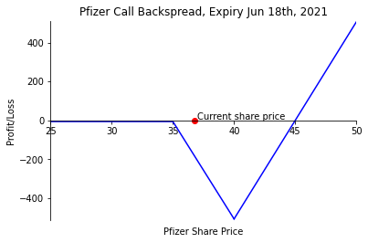

```python
fig2 = plt.figure()
ax2 = fig2.add_subplot(1,1,1)
ax2.set_title('Pfizer Call Backspread, Expiry Jun 18th, 2021')
ax2.set_xlabel('Pfizer Share Price')
ax2.xaxis.labelpad = 100
ax2.set_ylabel('Profit/Loss')
ax2.spines['bottom'].set_position('center')
ax2.spines['right'].set_color('none')
ax2.spines['top'].set_color('none')
ax2.set_xlim([25,50])
ax2.set_ylim([-510,510])
ax2.plot(36.75,0,'or')
ax2.text(37,5,'Current share price')
ax2.plot([25,35],[-6,-6],'blue')
ax2.plot([35,40],[-6,-506],'blue')
ax2.plot([40,50],[-506,506],'blue')
```

## Conclusions

In this project we have seen:

A COVID-19 vaccine would be the most important product released by Pfizer since their smallpox and polio drugs, which were developed before the company went public.

By utilizing an iron condor in the short-term, an investor can position themselves to take advantage of market volatility and uncertainty leading up to the release of a vaccine and American Presidential election.

By utilizing a call backspread with a longer 6-8 month term, an investor can hedge against any major drop in share price (in the case of a catastrophic vaccine release) while allowing for unlimited upside potential if the vaccine is a resounding success. This strategy would lose the most if the share price has only a small increase.